NetSimulator by NetSimR

# Simulation Report

Generated 20 November 2026, 13:55

## Key results

Losses ceded to the reinsurance layers per simulated period.

Mean

13,460,222

20,000 simulations

Median

13,339,890

Standard deviation

2,774,745

CV 0.206

VaR 99.5%

21,385,738

1 in 200

TVaR 99.5%

22,329,438

Average of the worst 0.5%

Maximum

25,718,291

Largest simulated total

## Model settings

Simulation

**Simulations**

20,000

**Seed**

Fixed at 1

**Processing**

Single process

Frequency

**Distribution**

Poisson

**Parameters**

lambda (mean claims) = 625

Severity

**Distribution**

Burr

**Parameters**

alpha (first shape) = 0.9314, gamma (second shape) = 1.2037, Scale = 23,086.3758

Tail adjustments

**Pareto slices**

Not applied

**Severity cap**

1,000,000

Each & every loss (EEL)

**Structure**

Limited Layer

**Limit**

750,000

**Deductible**

250,000

**Reinstatements**

Unlimited

Aggregate layer (AL)

**Structure**

None

## Gross, ceded and net

The structures are reinsurance layers, so the modelled totals are the ceded losses. Net is gross minus ceded.

| Metric | Gross | Ceded | Net |
| --- | --- | --- | --- |
| Mean | 47,335,635 | 13,460,222 | 33,875,413 |
| Share of gross mean | 100.0% | 28.4% | 71.6% |
| Standard deviation | 4,383,716 | 2,774,745 | 2,200,345 |
| Median | 47,200,390 | 13,339,890 | 33,836,420 |
| VaR 99% | 58,066,241 | 20,537,001 | 39,126,206 |
| VaR 99.5% | 59,213,612 | 21,385,738 | 39,712,635 |
| TVaR 99.5% | 60,789,084 | 22,329,438 | 40,402,726 |

Gross is after tail adjustments and the severity cap, before reinsurance. Each column's percentiles come from its own simulations, so net VaR is not gross VaR minus ceded VaR.

### Gross, Ceded, Net by return period

How the structures change the loss at each return period, on a log scale.

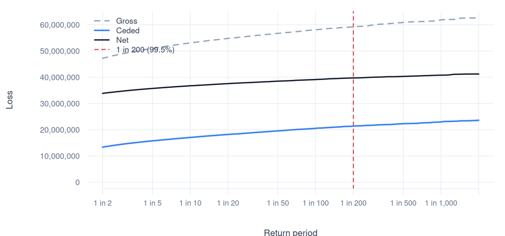

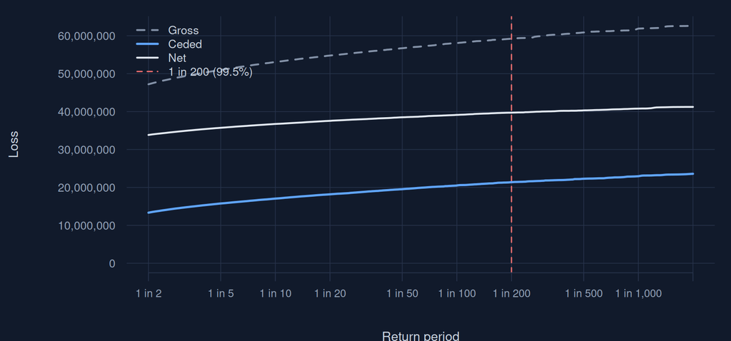

## Layer metrics

Figures a reinsurance price is usually built on, for the layers described under Model settings.

| Metric | Value | What it means |
| --- | --- | --- |
| Chance the layers are hit | 100.0% | Share of simulations with any ceded loss |
| Average loss when hit | 13,460,222 | Mean ceded loss over the simulations that hit the layers |
| Expected loss | 13,460,222 | Mean ceded loss over all simulations |
| Loss on line | 1794.70% | Expected loss as a share of the each-and-every-loss limit |
| Aggregate capacity | Unlimited | No aggregate limit or reinstatement limit applies |

## Statistics and tail risk

### Summary statistics

| Metric | Value |
| --- | --- |
| Simulations | 20,000 |
| Mean | 13,460,221.79 |
| Median | 13,339,890.22 |
| Standard deviation | 2,774,745.15 |
| Coefficient of variation | 0.206 |
| Minimum | 3,772,920.03 |
| Maximum | 25,718,291.39 |

### Percentiles, VaR and TVaR

| Percentile | Return period | VaR | TVaR |
| --- | --- | --- | --- |
| 50.0% | 1 in 2 | 13,339,890.22 | 15,677,375.96 |
| 75.0% | 1 in 4 | 15,283,210.48 | 17,071,883.42 |
| 90.0% | 1 in 10 | 17,053,629.98 | 18,578,472.72 |
| 95.0% | 1 in 20 | 18,182,906.53 | 19,581,093.43 |
| 97.5% | 1 in 40 | 19,236,868.63 | 20,524,358.13 |
| 99.0% | 1 in 100 | 20,537,001.48 | 21,622,794.33 |
| 99.5% | 1 in 200 | 21,385,738.42 | 22,329,438.28 |
| 99.6% | 1 in 250 | 21,611,872.78 | 22,541,086.33 |
| 99.8% | 1 in 500 | 22,290,796.48 | 23,189,162.16 |
| 99.9% | 1 in 1,000 | 22,953,133.43 | 23,819,291.22 |

### Simulation accuracy

| Metric | Value |
| --- | --- |
| Standard error of the mean | 19,620 |
| 95% range for the mean | 13,421,766 to 13,498,678 |
| 95% range for VaR 99.5% | 21,223,429 to 21,611,858 |
| Simulations at or beyond VaR 99.5% | 100 |

The ranges show how much the figures could move from simulation noise alone. Narrow ranges mean the run was large enough.

The range for the mean is a normal approximation (the mean plus or minus 1.96 standard errors), which is rough for heavy-tailed totals; when no total is negative it is kept at zero or above. The count at or beyond VaR 99.5% includes totals equal to VaR, so ties (e.g. many zero totals) can make it large.

## Claim frequency

Simulated number of claims per period, before severity and reinsurance.

| Metric | Value |
| --- | --- |
| Average claims per period | 625.06 |
| Standard deviation | 25.27 |
| Chance of no claims | 0.0% |
| 99th percentile | 685 |
| Maximum | 716 |

### Claims per period

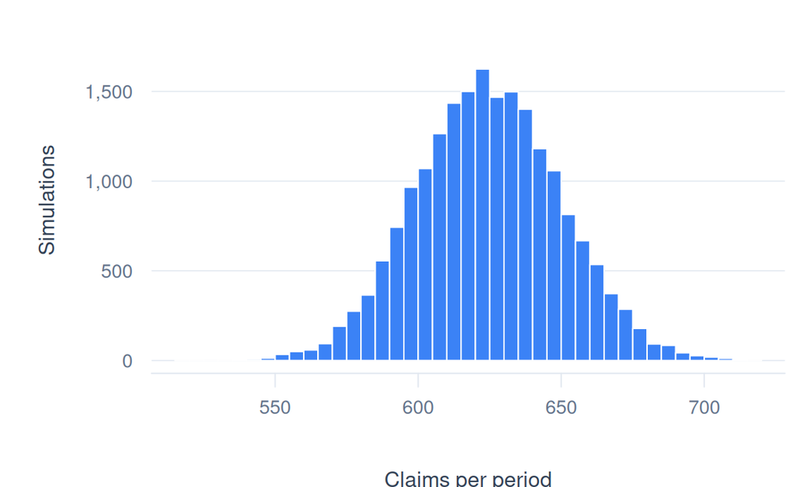

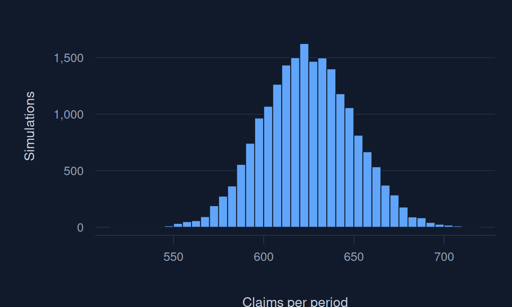

## Charts

### Distribution of total claims

Dashed lines mark the mean and the 99.5% VaR of all simulations.

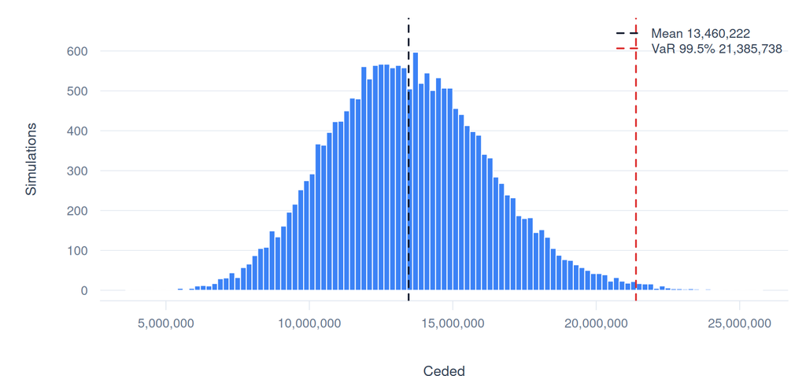

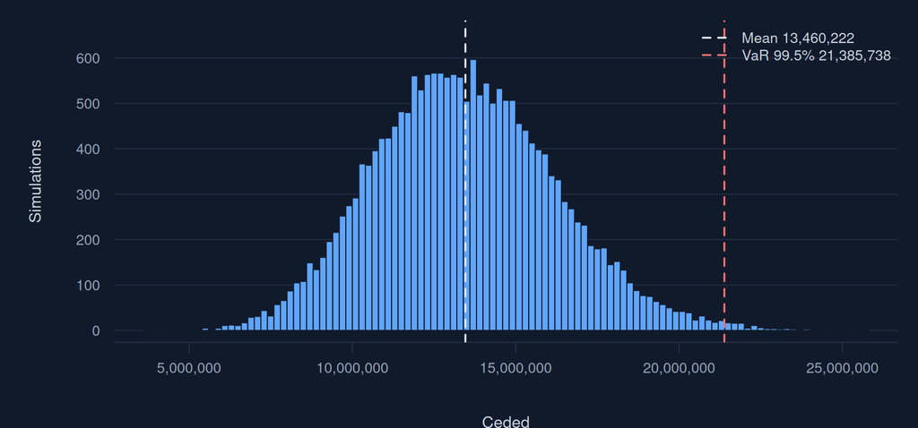

### Losses by return period

The loss expected once in each number of periods, on a log scale. Return periods are shown up to 1 in 2,000.

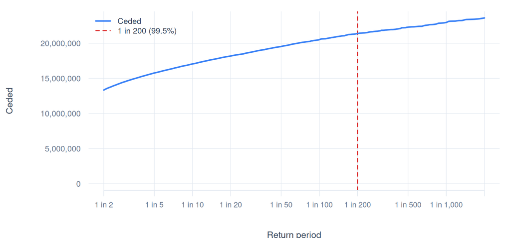

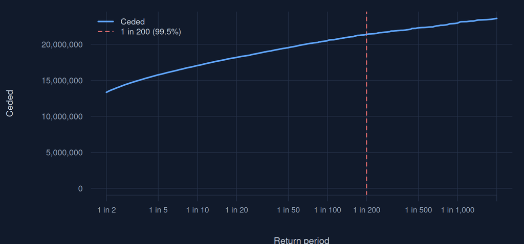

### Cumulative distribution

Share of simulations with total claims at or below each amount.

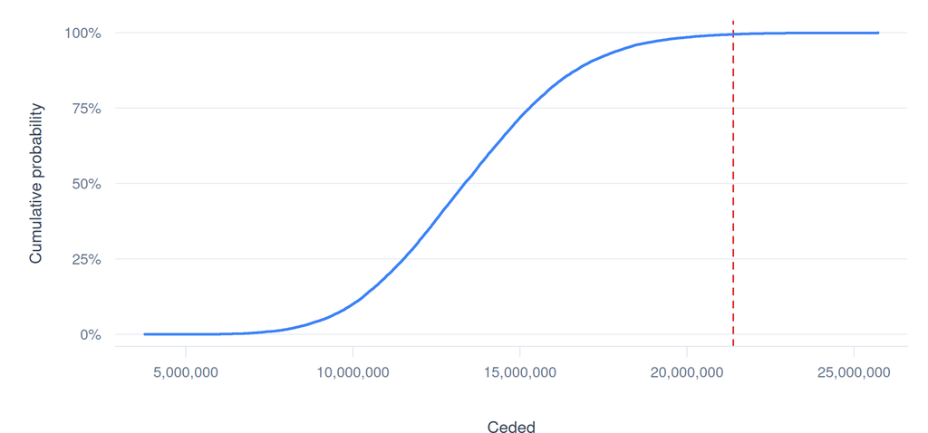

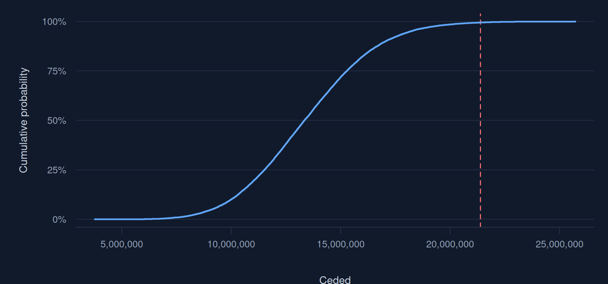

## How to read this report

- A large gap between the median and the tail percentiles points to a heavy-tailed outcome.
- VaR is the loss exceeded only with the stated probability. TVaR is the average loss in those worst cases, so it is always at least as large as VaR: TVaR 99.5% is the mean of the worst 0.5% of the simulations, rounded up to a whole number (here 100).
- The return period shows the same probability as a frequency: 99.5% corresponds to a 1 in 200 year event.
- Gross is before reinsurance. Ceded is what the layers pay, and net is what remains.
- The accuracy ranges reflect simulation noise only, not uncertainty in the chosen distributions or parameters.
- Figures reflect the tail adjustments and reinsurance structures listed under Model settings.